# Assignment 3: K Means Clustering

## Extension Exercise

Now, try to do the same for the data [collected in class](https://tccolumbia.qualtrics.com/SE/?SID=SV_6RRqlSAM6lZWYQt). Create two groups of clusters, the answers to the questions and regions where people grew up. Then create a visualization that shows the overlap between the two groups of clusters.

- Import class data, and structure:

```r
d1 <- read.table("cluster-class-data.csv", header = TRUE, sep = ",")
d2 <- select(d1, 4:16)
names(d2) <- c("cat","gif","timeinnymonths","siblings","sportsweekly","commutetoschoolmiles","androidfriends","moviesthisyear","classesthisterm","statesvisited","city","stateprovince","country")
d2$cat <- ifelse(d2$cat == "No",0,1) # codes 0 for no cat, 1 for cat
d2$gif <- ifelse(d2$gif == "j-iff",0,1) #codes 0 for "j-iff" (wrong pronunciation, 1 for "g-iff" (right pronunciation)
levels(d2$country)
```

```
##  [1] "chile"                        "china"
##  [3] "China"                        "CHINA"
##  [5] "India"                        "South Korea"
##  [7] "The United States of America" "United States"
##  [9] "United States "               "United States of America "
## [11] "USA"                          "Viet Nam "
## [13] "Vietnam"
```

```r
levels(d2$country)[levels(d2$country)=="United States "] <- "United States"
levels(d2$country)[levels(d2$country)=="United States of America "] <- "United States"
levels(d2$country)[levels(d2$country)=="The United States of America"] <- "United States"
levels(d2$country)[levels(d2$country)=="The United States of America "] <- "United States"
levels(d2$country)[levels(d2$country)=="USA"] <- "United States"
levels(d2$country)[levels(d2$country)=="china"] <- "China"
levels(d2$country)[levels(d2$country)=="Viet Nam "] <- "Vietnam"
levels(d2$country)[levels(d2$country)=="chile"] <- "Chile"

levels(d2$stateprovince)[levels(d2$stateprovince)=="BEIJING"] <- "Beijing"
levels(d2$stateprovince)[levels(d2$stateprovince)=="guangdong"] <- "Guangdong"
levels(d2$stateprovince)[levels(d2$stateprovince)=="MA "] <- "Massachusetts"
levels(d2$stateprovince)[levels(d2$stateprovince)=="valparaiso"] <- "Valparaiso"
levels(d2$stateprovince)[levels(d2$stateprovince)=="NJ"] <- "New Jersey"

levels(d2$city)[levels(d2$city)=="BEIJING"] <- "Beijing"
levels(d2$city)[levels(d2$city)=="shenzhen"] <- "Shenzhen"
levels(d2$city)[levels(d2$city)=="vina del mar"] <- "Vina Del Mar"
levels(d2$city)[levels(d2$city)=="Conway "] <- "Conway"
levels(d2$city)[levels(d2$city)=="Wellesley "] <- "Wellesley"

d2$commutetoschoolmiles[d2$commutetoschoolmiles == 9000] <- NA

d2$androidfriends[d2$androidfriends == 200] <- NA  # Bad data
d2$moviesthisyear[d2$moviesthisyear == 200] <- NA  # Bad data
```

- Scale data along all int, numeric, non-binary values:

```r
d3 <- dplyr::select(d2, c(1:10))
d3$timeinnymonths <- scale(d3$timeinnymonths)
d3$sportsweekly <- scale(d3$sportsweekly)
d3$commutetoschoolmiles <- scale(d3$commutetoschoolmiles)
d3$androidfriends <- scale(d3$androidfriends)
d3$moviesthisyear <- scale(d3$moviesthisyear)
d3$classesthisterm <- scale(d3$classesthisterm)
d3$statesvisited <- scale(d3$statesvisited)
```

- Omit NA:

```r
d4 <- na.omit(d3)
```

- Use kmeans to generate clusters:

```r
fit3 <- kmeans(d4, 4)
fit3$cluster
```

```
##  1  2  3  5  7  8  9 10 11 12 13 14 15 16 17 18 19 20 21 22
##  1  2  4  2  3  1  1  2  1  2  4  2  4  2  3  3  1  1  1  3
```

```r
d5 <- data.frame(d4, fit3$cluster)
names(d5)[names(d5) == "fit3.cluster"] <- "cluster"
d5$cluster <- as.factor(d5$cluster)
```

- Want to examine how cat ownership relates to the number of times a student plays a sport each week

```r
d6 <- select(d5, cat, sportsweekly, cluster)
d6 %>% group_by(cat, cluster)
```

```
## Source: local data frame [20 x 3]
## Groups: cat, cluster [7]
##
##      cat sportsweekly cluster
## *  <dbl>        <dbl>  <fctr>
## 1      0   0.04012093       1
## 2      0  -0.84253947       2
## 3      0  -0.84253947       4
## 4      0   0.04012093       2
## 5      0   2.68810212       3
## 6      1  -0.84253947       1
## 7      1   0.04012093       1
## 8      0   0.92278132       2
## 9      1  -0.84253947       1
## 10     1  -0.84253947       2
## 11     0  -0.84253947       4
## 12     0   0.04012093       2
## 13     0  -0.84253947       4
## 14     0   0.04012093       2
## 15     0   0.92278132       3
## 16     1   1.80544172       3
## 17     1  -0.84253947       1
## 18     1  -0.84253947       1
## 19     1  -0.84253947       1
## 20     0   0.92278132       3
```

```r
#d6 <- summarise(d6, avg = mean(sportsweekly))
# Error: Each variable must be a 1d atomic vector or list.
# Problem variables: 'sportsweekly'
```

- I’m totally stuck at this point. I’m not sure if I should be taking the average of all of the students of each group (cat owners and non cat owners), or if there is some other way to represent the cluster information.
- I understood the first example (student motivation), since the plot represented a change of motivation over time. It’s not clear to me what any continuum along the horizontal axis represents. It’s also not clear to me how to represent categorical data (e.g. cat ownership) using ggplot. :-/

## 10/22 Changes:

- Create new data frame for location data:

```r
loc <- dplyr::select(d2, 11:13)
loc <- lapply(loc, as.character)
```

- Install package for converting names of location data to coordinates:

```r
install.packages("ggmap", repos = "http://cran.us.r-project.org")
library(ggmap)
```

- Prepare data for reading into google maps:

```r
loc2 <- data.frame(lapply(loc, as.character, stringsAsFactors = FALSE))
loc3 <- tidyr::unite(loc2, location, city, stateprovince, country, sep = ", ")
```

- Add coordinate data

```r
loc3 <- mutate_geocode(loc3, location) # did confirm that "Hanoi, NA, Vietnam" returned the correct coordinates, even with missing state/province data
```

[output not shown]

[output not shown]

[output not shown]

[output not shown]

[output not shown]

[output not shown]

[output not shown]

[output not shown]

[output not shown]

[output not shown]

[output not shown]

[output not shown]

- Create new data frame, with only numeric location data

```r
loc4 <- dplyr::select(loc3, 2:3)
```

- Cluster location data using k-means, then create new data frame with appended cluster data

```r
fitloc <- kmeans(loc4, 4)
loc5 <- data.frame(loc4, fitloc$cluster)
names(loc5) <- c("lon", "lat", "cluster")
```

- Plot clustered location data

```r
install.packages('cluster', repos = "http://cran.us.r-project.org")
library(cluster)
```

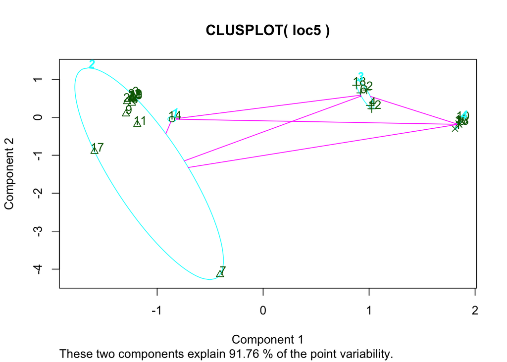

```r
clusplot(loc5, loc5$cluster, labels = 2, colors = TRUE)
```